# Fish graphs

Data has to have the following structure: * rownames = sites * colnames = species

## `MRFcov()` Markov Random Fields with covariates

This function is the workhorse of the MRFcov package, running separate penalized regressions for each node to estimate parameters of Markov Random Fields (MRF) graphs. Covariates can be included (a class of models known as Conditional Random Fields; CRF), to estimate how interactions between nodes vary across covariate magnitudes.

```r
fish_samp_mat <- read.csv(file = "binary_matrix_proposal.csv", header = TRUE, row.names = 1) %>%
  mutate_if(is.numeric, replace_na, replace = 0) %>%
  mutate_if(is.numeric, ~1 * (. != 0)) %>%
  as.matrix(.)
# write.table(fish_samp_mat, "fish sample matrix.csv", sep = ",", row.names = FALSE)
fish_mrf <- MRFcov(data = fish_samp_mat, n_nodes = 6, family = "gaussian") # symmetrise = mean
```

```
Fitting MRF models in sequence using 1 core ...

   |                                                  | 0 % ~calculating
```

```
Option grouped=FALSE enforced in cv.glmnet, since < 3 observations per fold
```

```
   |+++++++++                                         | 17% ~04s
```

```
Option grouped=FALSE enforced in cv.glmnet, since < 3 observations per fold
```

```
   |+++++++++++++++++                                 | 33% ~03s
```

```
Option grouped=FALSE enforced in cv.glmnet, since < 3 observations per fold
```

```
   |+++++++++++++++++++++++++                         | 50% ~02s
```

[output not shown]

`symmetrise`: The method to use for symmetrising corresponding parameter estimates (which are taken from separate regressions). Options are min (take the coefficient with the smallest absolute value), max (take the coefficient with the largest absolute value) or mean (take the mean of the two coefficients). Default is mean.

## `plotMRF_hm` Plot MRF interaction parameters as a heatmap

This function uses outputs from fitted MRFcov and bootstrap_MRF models to plot a heatmap of node interaction coefficients.

## `predict_MRF` Predict training observations from fitted MRFcov models

This function calculates linear predictors for node observations using coefficients from an MRFcov or MRFcov_spatial object.

Now let’s explore relationships:

[figure not shown]

# Including covariates

It is also highly advisable to scale any continuous variables so they all have mean = 0 and sd = 1 analysis (Clark’s recommendation from `vignette(CRF_data_prep)`)

A key step in the process of model exploration is to determine whether inclusion of covariates actually improves model fit and is warranted when estimating interaction parameters. (from vignette(Bird.parasites))

Ok, so far this was giving me one “snapshot”. Now I want to create graphs for 3 temperature ranges:

```r
# Fish matrices/data frames
fish_df <- read.csv(file = "fish sample matrix.csv", header = TRUE)
fish_mat <- read.csv(file = "fish sample matrix.csv", header = TRUE, row.names = 1) %>% as.matrix()
# Temperature tables
low_temp <- read.csv("low_temp_sites.csv", header = TRUE)
med_temp <- read.csv("medium_temp_sites.csv", header = TRUE)
high_temp <- read.csv("high_temp_sites.csv", header = TRUE)
```

## Low temperature

```r
lowtemp_model <- inner_join(fish_df, low_temp, by = 'site', na_matches = "never")
row.names(lowtemp_model) <- lowtemp_model$site
lowtemp_model$site <- NULL
lowtemp_model$max_temp <- scale(lowtemp_model$max_temp,
                                center = TRUE, scale = TRUE) # standardise temperatures (mean = 0; sd = 1)
View(lowtemp_model)
low_mrf <- MRFcov(data = lowtemp_model, n_nodes = 6, family = "gaussian") # symmetrise = mean
```

```
Fitting MRF models in sequence using 1 core ...

   |                                                  | 0 % ~calculating
   |+++++++++                                         | 17% ~00s
   |+++++++++++++++++                                 | 33% ~01s
   |+++++++++++++++++++++++++                         | 50% ~00s
   |++++++++++++++++++++++++++++++++++                | 67% ~00s
   |++++++++++++++++++++++++++++++++++++++++++        | 83% ~00s
   |++++++++++++++++++++++++++++++++++++++++++++++++++| 100% elapsed = 01s
```

```r
# I'm using gaussian just because it tells me there are non-binary data (but I cant find them. I noticed it's a lot faster)
# Note: D. sargus are always present and S. rubrum are always absent here
```

Plot co-occurrence

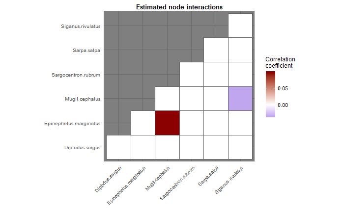

```r
# png("co_occurrence_low.png")
plotMRF_hm(low_mrf)
```

```r
# dev.off()
```

Now let’s explore relationships

```r
png("low temp network no labs.png")
plot.igraph(lowmod_network, layout = layout.circle(lowmod_network),
            edge.width = abs(E(lowmod_network)$weight),
            edge.color = ifelse(E(lowmod_network)$weight < 0,
                                'slateblue',
                                'darkred'),
            vertex.color = 'wheat',
            vertex.label = NA
            )
dev.off()
```

## Medium temperature

```r
medtemp_model <- inner_join(fish_df, med_temp, by = 'site', na_matches = "never")
row.names(medtemp_model) <- medtemp_model$site
medtemp_model$site <- NULL
medtemp_model$max_temp <- scale(medtemp_model$max_temp,
                                center = TRUE, scale = TRUE) # standardise temperatures (mean = 0; sd = 1)
View(medtemp_model)
med_mrf <- MRFcov(data = medtemp_model, n_nodes = 6, family = "gaussian") # symmetrise = mean
```

```
Fitting MRF models in sequence using 1 core ...

   |                                                  | 0 % ~calculating
   |+++++++++                                         | 17% ~00s
   |+++++++++++++++++                                 | 33% ~01s
   |+++++++++++++++++++++++++                         | 50% ~01s
   |++++++++++++++++++++++++++++++++++                | 67% ~01s
   |++++++++++++++++++++++++++++++++++++++++++        | 83% ~00s
   |++++++++++++++++++++++++++++++++++++++++++++++++++| 100% elapsed = 02s
```

```r
# Note: D. sargus are always present
```

Plot co-occurrence:

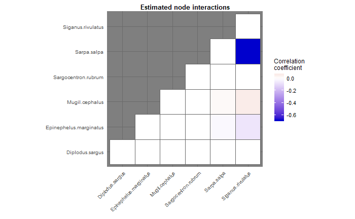

```r
# png("co_occurrence_med.png")
plotMRF_hm(med_mrf)
```

```r
# dev.off()
```

Now let’s explore relationships

```r
png("med temp network no labs.png")
plot.igraph(medmod_network, layout = layout.circle(medmod_network),
            edge.width = abs(E(medmod_network)$weight),
            edge.color = ifelse(E(medmod_network)$weight < 0,
                                'slateblue',
                                'darkred'),
            vertex.color = 'wheat',
            vertex.label = NA
            )
dev.off()
```

## High temperature

```r
hitemp_model <- inner_join(fish_df, high_temp, by = 'site', na_matches = "never")
row.names(hitemp_model) <- hitemp_model$site
hitemp_model$site <- NULL
hitemp_model$max_temp <- scale(hitemp_model$max_temp,
                                center = TRUE, scale = TRUE) # standardise temperatures (mean = 0; sd = 1)
View(hitemp_model)
hi_mrf <- MRFcov(data = hitemp_model, n_nodes = 6, family = "gaussian") # symmetrise = mean
```

```
Fitting MRF models in sequence using 1 core ...

   |                                                  | 0 % ~calculating
   |+++++++++                                         | 17% ~04s
   |+++++++++++++++++                                 | 33% ~03s
   |+++++++++++++++++++++++++                         | 50% ~02s
   |++++++++++++++++++++++++++++++++++                | 67% ~01s
   |++++++++++++++++++++++++++++++++++++++++++        | 83% ~01s
   |++++++++++++++++++++++++++++++++++++++++++++++++++| 100% elapsed = 03s
```

Plot co-occurrence:

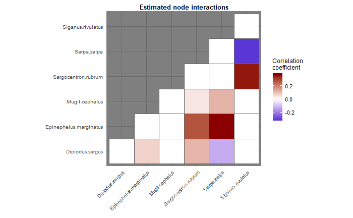

```r
# png("co_occurrence_hi.png")
plotMRF_hm(hi_mrf)
```

```r
# dev.off()
```

Now let’s explore relationships

```r
himod_network <- graph.adjacency(hi_mrf$graph, weighted = T, mode = "undirected")
png("hi temp network no labs.png")
plot.igraph(himod_network, layout = layout.circle(himod_network),
            edge.width = abs(E(himod_network)$weight),
            edge.color = ifelse(E(himod_network)$weight < 0,
                                'slateblue',
                                'darkred'),
            vertex.color = 'wheat',
            vertex.label = NA
            )
dev.off()
```

AWESOME!